# EXPLORATORY DATA ANALYSIS

Catherina Okoro

4/24/2021

# INTRODUCTION

In this project we explore the Covid 19 data and also look at population statistics for a number of countries.

The idea is to look at the common transmission mediums and evaluate the efficacy of various preventive measures put in place by the government.

The first dataset was downloaded from :

https://www.kaggle.com/tunguz/data-on-covid19-coronavirus

The second dataset on population figures was downloaded from the link below;

https://www.kaggle.com/vaishnavivenkatesan/world-population

The first dataset contains data on the spread of corona virus in the various countries.

The second dataset basically contains population figures for various countries.

```r
library(tidyverse)
library(janitor)
library(magrittr)
library(knitr)

covid_data = read.csv("owid-covid-data.csv") %>%
  clean_names()
population_data = read.csv("WorldPopulation.csv") %>%
  clean_names()
```

# TIDYING THE DATA

The population dataset is in wide format, we will convert it in longer format before merging it with the covid dataset.

```r
population_long = population_data %>%
                    pivot_longer(names_to = "year",
                    cols = starts_with("x"),
                    values_to = "population")
```

The population figures are now placed in one column and the corresponding years are also placed in one column.

# JOINING/MERGING

I want to bring the population column from the population dataset into the covid dataset.

I use the country code as my primary key.

```r
#rename the iso-code to country code
covid_data %<>%
  rename(country_code = iso_code)

full_data = right_join(covid_data, population_long,
                       by = "country_code")



full_data = full_data[sample(nrow(full_data), 1000), ]
```

# WRANGLING

```r
full_data %<>%
  mutate(bin_cases = case_when(
    total_cases <= 10 ~ "Not severe",
    total_cases > 10 ~ "Severe"
  ))


full_data %>%
  group_by(bin_cases) %>%
  summarise(mean = mean(population, na.rm = TRUE),
            sd = sd(population, na.rm = TRUE),
            var = var(population, na.rm = TRUE),
            n = n(),
            min = min(population, na.rm = TRUE),
            max = max(population, na.rm = TRUE)) %>%
  kable()
```

| bin_cases | mean | sd | var | n | min | max |
| --- | --- | --- | --- | --- | --- | --- |
| Not severe | 17147245 | 31508487 | 9.927847e+14 | 52 | 18388 | 148160129 |
| Severe | 26084627 | 99120796 | 9.824932e+15 | 927 | 16493 | 1241935000 |
| NA | 19154750 | 75311091 | 5.671760e+15 | 21 | 10357 | 345006493 |

```r
full_data %>%
  group_by(bin_cases) %>%
  summarise(mean = mean(total_cases, na.rm = TRUE),
            sd = sd(total_cases, na.rm = TRUE),
            var = var(total_cases, na.rm = TRUE),
            n = n(),
            min = min(total_cases, na.rm = TRUE),
            max = max(total_cases, na.rm = TRUE)) %>%
  kable()
```

| bin_cases | mean | sd | var | n | min | max |
| --- | --- | --- | --- | --- | --- | --- |
| Not severe | 3.653846e+00 | 2.862089e+00 | 8.191553e+00 | 52 | 1 | 10 |
| Severe | 3.013180e+05 | 1.632384e+06 | 2.664678e+12 | 927 | 11 | 31575640 |
| NA | NaN | NA | NA | 21 | Inf | -Inf |

From the descriptive statistics we can see the range and distribution pf the variables in question.

# VISUALIZATION

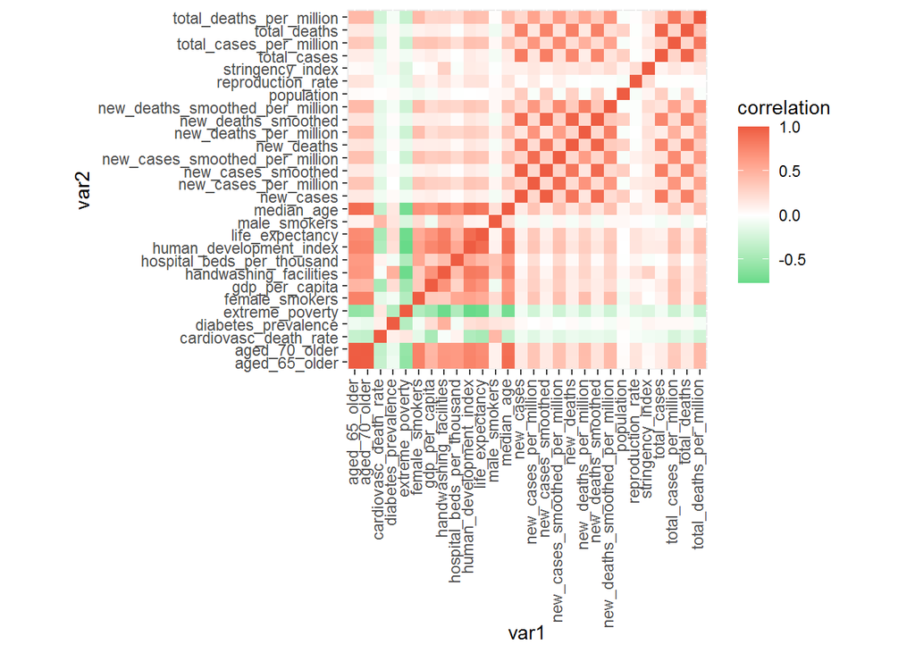

```r
# correlation map
cormat <- full_data %>% select_if(is.numeric) %>% cor(use = "pair")

tidycor <- cormat %>% as.data.frame %>% rownames_to_column("var1") %>%
    pivot_longer(-1, names_to = "var2", values_to = "correlation")

tidycor %>% ggplot(aes(var1, var2, fill = correlation)) + geom_tile() +
    scale_fill_gradient2(low = "springgreen3", mid = "white",
        high = "tomato2") + coord_fixed() + theme(axis.text.x =     element_text(angle = 90,
    hjust = 1, vjust = 0.2))
```

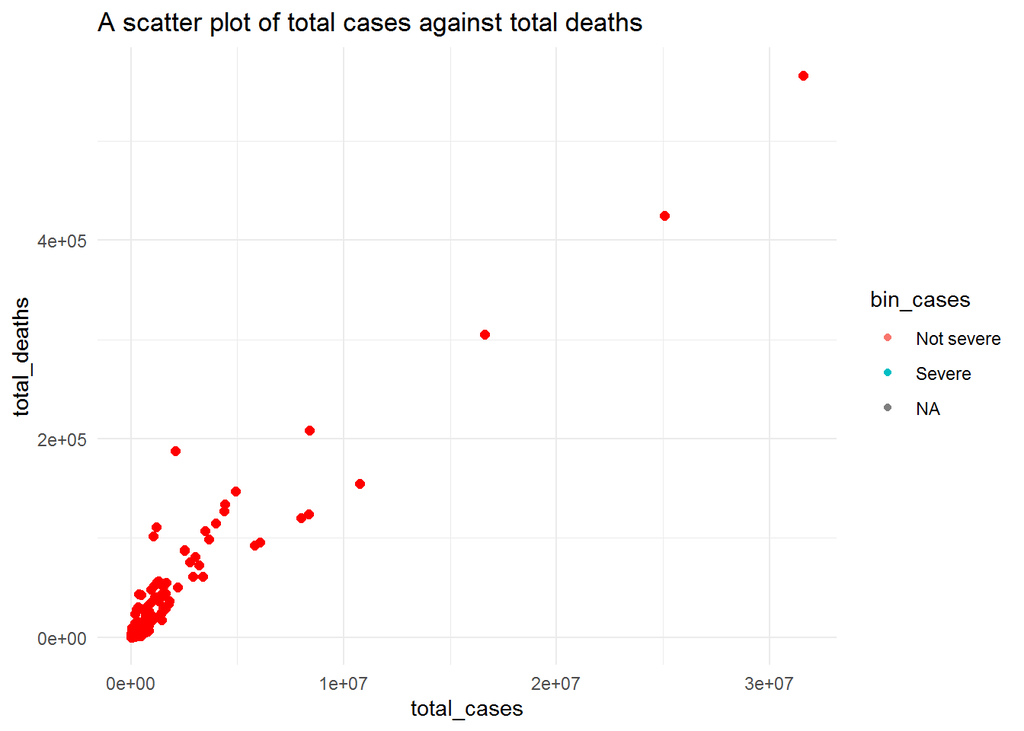

```r
#other visualizations

ggplot(full_data, aes(x = total_cases, y = total_deaths,
                      color = bin_cases)) +
  geom_point() +
  stat_summary(fun = "median", colour = "red", size = 2,
               geom = "point") +
  ggtitle("A scatter plot of total cases against total deaths") +
  theme_minimal()
```

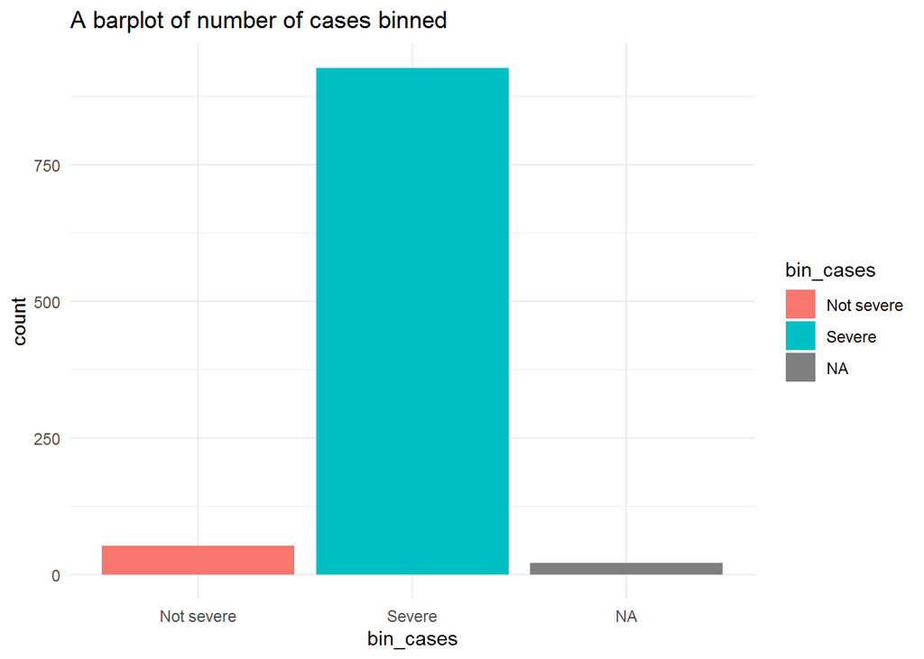

```r
ggplot(full_data) +
  geom_bar(aes(x = bin_cases, fill = bin_cases)) +
  ggtitle("A barplot of number of cases binned") +
  theme_minimal()
```

# DIMENSIONALITY REDUCTION

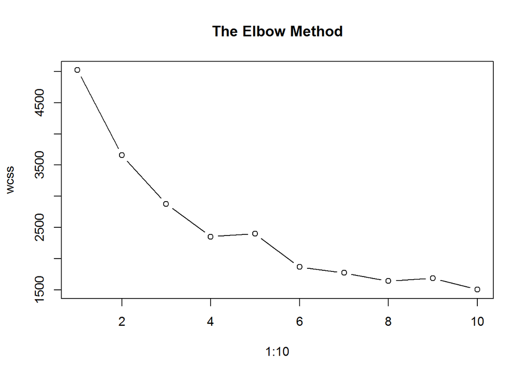

```r
# Feature Scaling


numeric_df = full_data %>%
  na.omit() %>%
  select(total_cases:human_development_index)


numeric_df = scale(numeric_df)

# Using the elbow method to find the optimal number of clusters
set.seed(6)
wcss = vector()
for (i in 1:10) wcss[i] = sum(kmeans(numeric_df, i)$withinss)
plot(1:10,
     wcss,
     type = 'b',
     main = paste('The Elbow Method'))
```

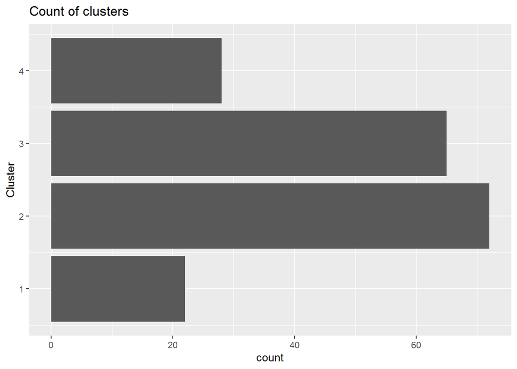

```r
# Fitting K-Means to the dataset
set.seed(29)
kmeans = kmeans(x = numeric_df, centers = 4)
y_kmeans = kmeans$cluster

# Visualising the clusters
kmeans_basic_table <- data.frame(kmeans$size, kmeans$centers)
kmeans_basic_df <- data.frame(Cluster = kmeans$cluster, numeric_df)

#using ggplot
ggplot(kmeans_basic_df, aes(y = Cluster)) +
  geom_bar() +
  ggtitle("Count of clusters")
```

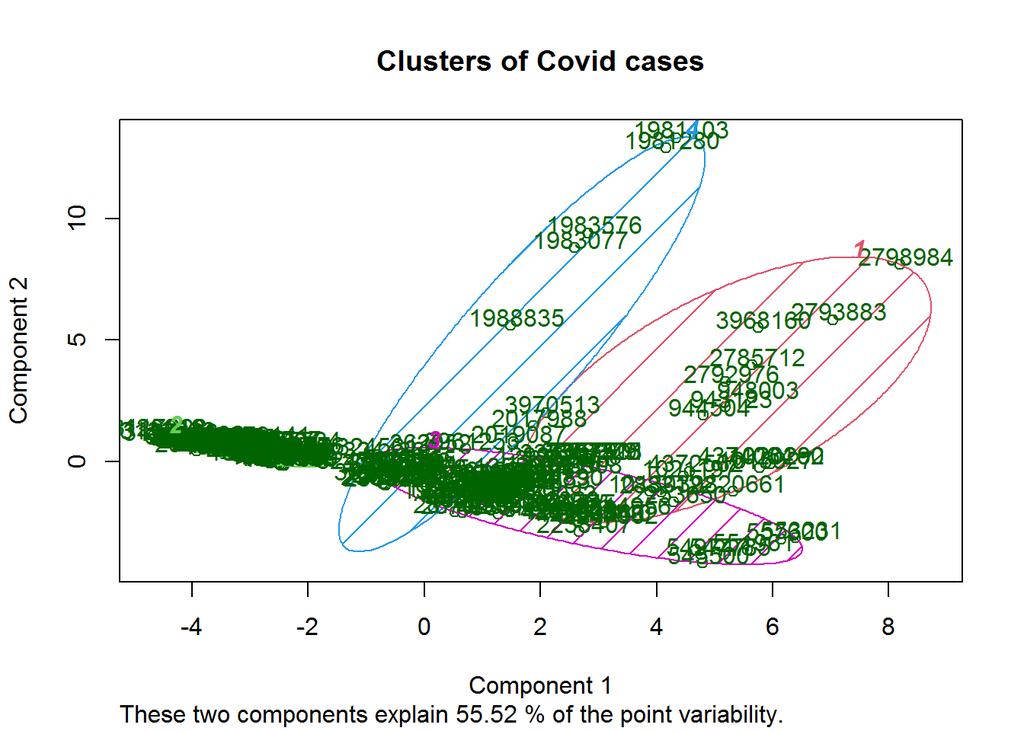

```r
#use cluster library to get the variance explained
library(cluster)
clusplot(numeric_df,
         y_kmeans,
         lines = 0,
         shade = TRUE,
         color = TRUE,
         labels = 2,
         plotchar = FALSE,
         span = TRUE,
         main = paste('Clusters of Covid cases')
         )
```

Using the elbow method we find four as the optimal number of clusters.